# xwMOOC 데이터 제품

등록된 자동차 현황 - 성남시

# 1. 디젤차? [^1]

자동차 배기가스 통제를 강화하면 공기질이 좋아질 것인가? 전세계 대도시의 공기품질 향상을 위해서 다양한 실험을 진행중에 있고, 베이징도 자동차 배기가스 통제를 비롯한 도심 공기청정기술을 도입하는 등 다양한 시도를 취하고 있다.

공기품질을 높일 수 있는 여러방안이 있지만 가장 먼저 자동차 등록대수 현상파악부터 시작을 해 보자.

# 2. 자동차 등록현황 데이터

국토교통 통계누리 자동차등록현황보고 (Total Registered Moter Vehicles) 웹사이트를 통해 자동차 등록현황 데이터를 다운로드 받아볼 수 있다.

웹사이트에서 다운로드 받은 데이터가 깔끔한 형태가 아니라서, 데이터를 깔끔하게 정제작업을 수행한다.

```r
library(tidyverse)
library(readxl)
library(xts)
library(extrafont)
loadfonts()
library(ggthemes)
library(DT)
library(treemap)
library(highcharter)
library(d3treeR)

# 1. 데이터 가져오기 -----
auto_dat <- read_excel("data/자동차대수/2018년_01월_자동차_등록자료_통계.xlsx", sheet="02.통계표_시군구", skip=3)

# 2. 데이터 정제 -----

auto_dat <- auto_dat %>%
    select("X__1", "X__2", "관용", "자가용", "영업용", "관용__1",
             "자가용__1", "영업용__1", "관용__2", "자가용__2", "영업용__2",
             "관용__3", "자가용__3", "영업용__3") %>%
    rename(시도=X__1, 시군구=X__2) %>%
    mutate(시도 = na.locf(시도)) %>%
    filter(시군구 != "계") %>%
    rename(승용_관용 = "관용",
           승용_자가용 = "자가용",
           승용_영업용 = "영업용",
           승합_관용 = "관용__1",
           승합_자가용 = "자가용__1",
           승합_영업용 = "영업용__1",
           화물_관용   = "관용__2",
           화물_자가용 = "자가용__2",
           화물_영업용 = "영업용__2",
           특수_관용   = "관용__3",
           특수_자가용 = "자가용__3",
           특수_영업용 = "영업용__3")

승용_df <- auto_dat %>% select(시도, 시군구, contains("승용")) %>%
    gather(용도, 대수, -시도, -시군구)

화물_df <- auto_dat %>% select(시도, 시군구, contains("화물")) %>%
    gather(용도, 대수, -시도, -시군구)

특수_df <- auto_dat %>% select(시도, 시군구, contains("특수")) %>%
    gather(용도, 대수, -시도, -시군구)

auto_df <- bind_rows(승용_df, 화물_df, 특수_df)
```

# 3. 시군구별 자동차 등록현황 통계

정제가 완료된 데이터를 차량유형별, 차량용도별로 표로 만들어 살펴보자.

## 3.1. 차량유형별

승용, 특수, 화물 차량 유형별로 살펴보자.

```r
# 2. 데이터 정제하기 -----
auto_df <- auto_df %>%
    separate(용도, into=c("차량", "용도")) %>%
    separate(시군구, into=c("시군", "시군구"), sep=" ", fill="right") %>%
    mutate(시군구 = ifelse(is.na(시군구), 시군, 시군구))

## 2.1. 시도별 차량유형별 차량 등록대수표

auto_df %>% group_by(차량, 시도) %>%
    summarize(대수 = sum(대수)) %>%
    arrange(desc(대수)) %>%
    spread(차량, 대수) %>%
    datatable(options = list(pageLength = 10),
              autoHideNavigation = getOption("DT.autoHideNavigation", NULL)) %>%
    formatCurrency(c("승용", "특수", "화물"), currency="", interval=3, digits=0)
```

|  | 시도 | 승용 | 특수 | 화물 |
| --- | --- | --- | --- | --- |
| 1 | 강원 | 562495 | 2738 | 151935 |
| 2 | 경기 | 4391926 | 15687 | 778411 |
| 3 | 경남 | 1316801 | 7278 | 289250 |
| 4 | 경북 | 1025317 | 7217 | 312047 |
| 5 | 광주 | 535907 | 2335 | 90980 |
| 6 | 대구 | 959617 | 2717 | 163183 |
| 7 | 대전 | 549149 | 2254 | 86889 |
| 8 | 부산 | 1089062 | 10068 | 191084 |
| 9 | 서울 | 2644378 | 7656 | 339460 |
| 10 | 세종 | 112149 | 282 | 14852 |

[output cut: 7 more lines]

## 3.2. 차량용도별

관용, 영업용, 자가용 차량용도별로 살펴보자.

```r
auto_df %>% group_by(용도, 시도) %>%
    summarize(대수 = sum(대수)) %>%
    arrange(desc(대수)) %>%
    spread(용도, 대수) %>%
    datatable(options = list(pageLength = 10),
              autoHideNavigation = getOption("DT.autoHideNavigation", NULL)) %>%
    formatCurrency(c("관용", "영업용", "자가용"), currency="", interval=3, digits=0)
```

|  | 시도 | 관용 | 영업용 | 자가용 |
| --- | --- | --- | --- | --- |
| 1 | 강원 | 4057 | 21074 | 692037 |
| 2 | 경기 | 12283 | 191060 | 4982681 |
| 3 | 경남 | 4848 | 74850 | 1533631 |
| 4 | 경북 | 5165 | 42691 | 1296725 |
| 5 | 광주 | 1520 | 30148 | 597554 |
| 6 | 대구 | 2220 | 43472 | 1079825 |
| 7 | 대전 | 1306 | 26109 | 610877 |
| 8 | 부산 | 3359 | 86203 | 1200652 |
| 9 | 서울 | 8552 | 183602 | 2799340 |
| 10 | 세종 | 539 | 2039 | 124705 |

[output cut: 7 more lines]

# 4. 자동차 등록현황 시각화

## 4.1. 시도별 자동차 등록대수

시도별 자동차 등록대수를 정적 그래프를 통해 시각화해보자.

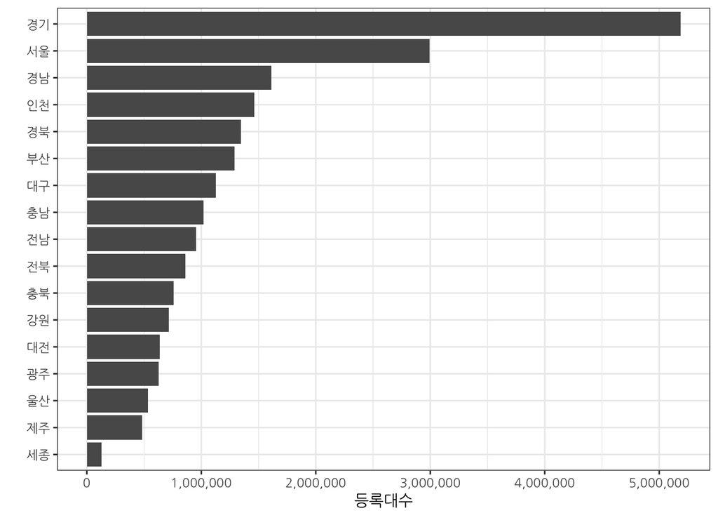

```r
# 3. 시각화 -----
## 3.1. 시도별 차량 등록대수
auto_df %>% group_by(시도) %>%
    summarize(대수 = sum(대수)) %>%
    arrange(desc(대수)) %>%
    ggplot(aes(x=fct_reorder(시도, 대수), y=대수)) +
      geom_col() +
      coord_flip() +
      labs(y="등록대수", x="") +
      scale_y_continuous(labels = scales::comma) +
      theme_bw(base_family="NanumGothic")
```

## 4.2. 시군구별 자동차 등록현황

시도별, 시군구별 자동차 등력현황을 `treemap`을 통해 시각화해 보자.

```r
## 3.2. treemap: 시도, 시군, 시군구, 차량
auto_treemap_df <- auto_df %>% group_by(시도, 시군, 시군구, 차량) %>%
    summarize(대수 = sum(대수))

auto_treemap <- treemap(auto_treemap_df,
                            index = c("시도", "시군", "시군구", "차량"),
                            vSize = "대수",
                            vColor = "대수",
                            title = "차량등록대수",
                            fontsize.labels=c(12, 8),
                            draw = FALSE,
                            type = "value",
                            format.legend = list(scientific = FALSE, big.mark = ","),
                            title.legend="")
```

```r
d3tree2(auto_treemap, rootname = "대한민국")
```

[interactive chart not shown]

[^1]: [CAR GUY - 디젤차 금지 베이징, 미세먼지 서울보다 좋아져 이변](http://www.carguy.kr/china/28732/)